# Machine Learning : Stroke Prediction

### Name : Nikhil Horakeri

# Stroke Prediction

- Section 1 - Introduction
  - Section 1.1 - Report Overview
  - Section 1.2 - Overview of Methodology
- Section 2 - Predictive Modelling
  - Section 2.1 - Feature Selection
  - Section 2.2 - Model Fitting and Tuning
  - Section 2.3 - Model Comparision
- Section 3 - Critique & Limitations
- Section 4 - Summary & Conclusions
  - Section 4.1 - Project Summary
  - Section 4.2 - Summary of Findings
  - Section 4.3 - Conclusions
- Section 5 - References

# Task 1) Introduction:

### Task 1.1 ) Report Overview :

- Section 1.2 - Overview of Methodology - Outlines the methodology
- Section 2 - Predictive Modelling - Describes the process of making models for prediction using specific classifiers
- Section 2.1 - Feature Selection - Describes the top best features based on importance
- Section 2.2 - Model Fitting and Tuning - Describes the process of selecting a best set of parameters for a specific classifier
- Section 2.3 - Model Comparision - Model performance comparision results
- Section 3 - Critique & Limitations - Describes the strength and weakness of the project
- Section 4 - Summary & Conclusions - Describes the conclusion , findings and the overall summary of the project

### Task 1.2) Overview of Methodology :

I will consider the following classifiers for the prediction of the target variable stroke:

- K-Nearest Neighbor(KNN)
- Decision Tree
- Random Forest

The dataset was preprocessed in Phase 1. The preprocessing involved dealing with the missing values, checking for the irrelevant features, dealing with the outliers and trying to understand with visualisation as to which features are important. In this phase 2, before the feature selection is performed the dataset has to be transformed using the following steps:

1. bin the descriptive feature age
2. one hot encoding to - age, gender , ever_married , work_type, residence_type, smoking_status
3. Label encode of the target feature - stroke
4. Split the dataset into features and target(stroke)
5. normalise the numerical descriptive features - MinMax(0-1)

The dataset is imbalanced as it has 3223 rceords for no_stroke(target=0) and 114 records for stroke(target=1). So before the feature selection is performed the dataset is split into train and test and the train data is oversampled with the minority class using the below steps:

1. Split the dataset into train and test (70:30)
2. To deal with the imbalanced data - Oversample the data to increase the records of the minority class (stroke = 1) in the training data
3. Find the top features using train data and cross validation by using the filter method - Fscore
4. Assess the performance of these top 6 features using the test data

After the feature selection is performed we get 6 best features. These 6 best features of the training data will be used for hyperparameter tuning using GridSearchCV and cross validation on each of the three classifiers mentioned above, considering the Roc_auc as the scoring_metric. After the 3 models are tuned we will fit 5 fold cross validation on the test set and perform the paired t-tests to compare each of the models, to check if any performance difference is statistically significant. We also compare the classifiers with respect to the recall score and the confusion matrices on the test data.

# Task 2) Predictive Modelling :

```python
# importing the required libraries
import pandas as pd
import numpy as np
from sklearn import preprocessing
from sklearn.model_selection import cross_val_score, RepeatedStratifiedKFold
import sklearn.metrics as metrics
from sklearn.ensemble import RandomForestClassifier
from sklearn import preprocessing
from sklearn import feature_selection as fs
from sklearn.neighbors import KNeighborsClassifier
from sklearn.model_selection import GridSearchCV
import matplotlib.pyplot as plt
%matplotlib inline
%config InlineBackend.figure_format = 'retina'
from sklearn.model_selection import cross_val_score
from scipy import stats
```

```python
import warnings
warnings.filterwarnings("ignore")
```

```python
# import the dataset
df = pd.read_csv('stroke_prediction.csv')
```

```python
# set the id column as index
df = df.set_index('id')
df.head(5)
```

| id | gender | age | hypertension | heart_disease | ever_married | work_type | Residence_type | avg_glucose_level | bmi | smoking_status | stroke |
| --- | --- | --- | --- | --- | --- | --- | --- | --- | --- | --- | --- |
| 31112 | Male | 80.0 | 0 | 1 | Yes | Private | Rural | 105.92 | 32.5 | never smoked | 1 |
| 53882 | Male | 74.0 | 1 | 1 | Yes | Private | Rural | 70.09 | 27.4 | never smoked | 1 |
| 10434 | Female | 69.0 | 0 | 0 | No | Private | Urban | 94.39 | 22.8 | never smoked | 1 |
| 12109 | Female | 81.0 | 1 | 0 | Yes | Private | Rural | 80.43 | 29.7 | never smoked | 1 |
| 12095 | Female | 61.0 | 0 | 1 | Yes | Govt_job | Rural | 120.46 | 36.8 | smokes | 1 |

```python
# create a copy of the data frame and store it in the stroke_age_bin variable
stroke_age_bin = df.copy()
```

```python
# check the make sure that all the descriptive features have the correct datatype
stroke_age_bin.dtypes
```

```
gender                object
age                  float64
hypertension           int64
heart_disease          int64
ever_married          object
work_type             object
Residence_type        object
avg_glucose_level    float64
bmi                  float64
smoking_status        object
stroke                 int64
dtype: object
```

```python
# the features hypertension and heart disease should be converted to object
# as these two features are nominal descriptive features
stroke_age_bin['hypertension'] = stroke_age_bin['hypertension'].astype('object')
stroke_age_bin['heart_disease'] = stroke_age_bin['heart_disease'].astype('object')

# check to make sure the above features are converted to object
stroke_age_bin.dtypes
```

```
gender                object
age                  float64
hypertension          object
heart_disease         object
ever_married          object
work_type             object
Residence_type        object
avg_glucose_level    float64
bmi                  float64
smoking_status        object
stroke                 int64
dtype: object
```

#### Discretize the descriptive feature age

```python
# the feature age will be discritised as young(0.079, 30.0), middle-aged(30.0, 53.0) and old (53.0, 82.0)
stroke_age_bin['age'] = pd.qcut(stroke_age_bin['age'] , q=3, labels=['young','middle-aged','old'])

# check to make sure that the variable age is discrtised
stroke_age_bin['age'].value_counts()
```

```
middle-aged    1139
young          1113
old            1085
Name: age, dtype: int64
```

#### One hot encoding for nominal descriptive features:

```python
# one hot encoding to - gender , ever_married , work_type, residence_type, smoking_status, age
# list of nominal descriptive features
col_category = stroke_age_bin.columns[stroke_age_bin.dtypes == object].tolist()
```

```python
# gender , ever_married and residence_type features have only 2 levels so only one binary feature should be created
for feature in col_category:
    length = len(stroke_age_bin[feature].unique())
    if(length==2):
        stroke_age_bin[feature] = pd.get_dummies(stroke_age_bin[feature], drop_first=True)
```

```python
# apply get dummies method on the remainig categorical features
stroke_age_bin = pd.get_dummies(stroke_age_bin)
```

```python
# check to make sure the categorical features are one hot encoded
stroke_age_bin.head(5)
```

| id | gender | hypertension | heart_disease | ever_married | Residence_type | avg_glucose_level | bmi | stroke | age_young | age_middle-aged | age_old | work_type_Govt_job | work_type_Never_worked | work_type_Private | work_type_Self-employed | work_type_children | smoking_status_formerly smoked | smoking_status_never smoked | smoking_status_smokes |
| --- | --- | --- | --- | --- | --- | --- | --- | --- | --- | --- | --- | --- | --- | --- | --- | --- | --- | --- | --- |
| 31112 | 1 | 0 | 1 | 1 | 0 | 105.92 | 32.5 | 1 | 0 | 0 | 1 | 0 | 0 | 1 | 0 | 0 | 0 | 1 | 0 |
| 53882 | 1 | 1 | 1 | 1 | 0 | 70.09 | 27.4 | 1 | 0 | 0 | 1 | 0 | 0 | 1 | 0 | 0 | 0 | 1 | 0 |
| 10434 | 0 | 0 | 0 | 0 | 1 | 94.39 | 22.8 | 1 | 0 | 0 | 1 | 0 | 0 | 1 | 0 | 0 | 0 | 1 | 0 |
| 12109 | 0 | 1 | 0 | 1 | 0 | 80.43 | 29.7 | 1 | 0 | 0 | 1 | 0 | 0 | 1 | 0 | 0 | 0 | 1 | 0 |
| 12095 | 0 | 0 | 1 | 1 | 0 | 120.46 | 36.8 | 1 | 0 | 0 | 1 | 1 | 0 | 0 | 0 | 0 | 0 | 0 | 1 |

#### Label Encode :

```python
# the target feature - stroke is already label encoded where 0 - no stroke and 1 - stroke
stroke_age_bin['stroke'].value_counts()
```

```
0    3223
1     114
Name: stroke, dtype: int64
```

#### Split the dataset into features and target(stroke) :

```python
# create a dataframe for the descriptive features by dropping the target variable stroke
data = stroke_age_bin.drop('stroke', axis = 1)

# store the target variable stroke in a variable called target
target = stroke_age_bin['stroke']
```

#### Normalise the numerical descriptive features:

```python
# Scaling the descriptive features to range from 0 to 1 using the MinMaxSclaer()
Data = preprocessing.MinMaxScaler().fit_transform(data)
```

```python
# After the MinMaxScaler is applied, the dataframe is converted to a numpy array.
# So convert the numpy array back to a dataframe so it will be easy to oversample the data
desc_feature = pd.DataFrame(Data, columns=['gender', 'hypertension', 'heart_disease', 'ever_married',
       'Residence_type', 'avg_glucose_level', 'bmi', 'age_young','age_middle-aged', 'age_old', 'work_type_Govt_job',
        'work_type_Never_worked', 'work_type_Private', 'work_type_Self-employed', 'work_type_children',
       'smoking_status_formerly smoked', 'smoking_status_never smoked','smoking_status_smokes'])
```

#### Split the dataset into train and test:

```python
# split the data into train and test
from sklearn.model_selection import train_test_split
D_train, D_test, t_train, t_test = train_test_split(desc_feature, target, test_size=0.3, random_state=999, stratify=target)
```

```python
# conatenate the training data (D_train and t_train to oversample the minority class)
df_concat = D_train
df_concat['stroke'] = t_train.values
df_concat.head(5)
```

|  | gender | hypertension | heart_disease | ever_married | Residence_type | avg_glucose_level | bmi | age_young | age_middle-aged | age_old | work_type_Govt_job | work_type_Never_worked | work_type_Private | work_type_Self-employed | work_type_children | smoking_status_formerly smoked | smoking_status_never smoked | smoking_status_smokes | stroke |
| --- | --- | --- | --- | --- | --- | --- | --- | --- | --- | --- | --- | --- | --- | --- | --- | --- | --- | --- | --- |
| 774 | 0.0 | 0.0 | 0.0 | 1.0 | 1.0 | 0.603972 | 0.340483 | 0.0 | 0.0 | 1.0 | 0.0 | 0.0 | 0.0 | 1.0 | 0.0 | 0.0 | 1.0 | 0.0 | 0 |
| 206 | 0.0 | 0.0 | 0.0 | 0.0 | 0.0 | 0.257808 | 0.198391 | 1.0 | 0.0 | 0.0 | 0.0 | 0.0 | 0.0 | 0.0 | 1.0 | 0.0 | 1.0 | 0.0 | 0 |
| 2147 | 0.0 | 0.0 | 0.0 | 1.0 | 0.0 | 0.280203 | 0.584450 | 0.0 | 1.0 | 0.0 | 0.0 | 0.0 | 0.0 | 1.0 | 0.0 | 0.0 | 1.0 | 0.0 | 0 |
| 80 | 1.0 | 0.0 | 0.0 | 1.0 | 1.0 | 0.489196 | 0.581769 | 0.0 | 0.0 | 1.0 | 0.0 | 0.0 | 1.0 | 0.0 | 0.0 | 1.0 | 0.0 | 0.0 | 1 |
| 2276 | 0.0 | 0.0 | 0.0 | 0.0 | 1.0 | 0.085907 | 0.227882 | 1.0 | 0.0 | 0.0 | 0.0 | 0.0 | 1.0 | 0.0 | 0.0 | 0.0 | 1.0 | 0.0 | 0 |

#### Oversample the data to solve the imbalanced data problem:

```python
from sklearn.utils import resample
# Seperate the majority and the minority class
df_majority_nostroke = df_concat[df_concat.stroke == 0]
df_minority_stroke = df_concat[df_concat.stroke == 1]

# upsample the minority class to increase the number of samples for stroke = 1
df_minority_stroke_upsampled = resample(df_minority_stroke, replace=True, n_samples = 2000, random_state = 999)

# Combine the majority class(stroke = 0) with the upsampled minority class(stroke = 1)
df_oversampled = pd.concat([df_majority_nostroke, df_minority_stroke_upsampled])

# check the value counts to make sure the minority class is upsampled
df_oversampled.stroke.value_counts()

# Conclusion : So the data is oversampled with 2000 samples for the minority class(stroke = 1)
```

```
0    2255
1    2000
Name: stroke, dtype: int64
```

```python
# create a numpy array for the descriptive features by dropping the target variable stroke
D_train = df_oversampled.drop(columns= 'stroke').values

# store the target variable in t_train
t_train = df_oversampled['stroke']

# change the D_test to numpy array
D_test = D_test.values

# all the above are converted to numpy array for further processing
```

### Task 2.1) Feature Selection :

```python
# intialise the cross validation method
cv_method = RepeatedStratifiedKFold(n_splits=5, n_repeats=3,random_state=999)
```

```python
from sklearn.tree import DecisionTreeClassifier
clf = DecisionTreeClassifier(random_state=999)
```

```python
# set the scoring metric to be used
scoring_metric = 'roc_auc'
```

```python
 # function to determine the performance with the selected features on test data
def performance_selected_features(fs_indices):
    cv_results = cross_val_score(estimator=clf,
                             X=D_test[:, fs_indices],
                             y=t_test,
                             cv=cv_method,
                             scoring=scoring_metric)
    mean_score = cv_results.mean().round(3)
    return(mean_score)
```

```python
# Determine which feature selection to use :
# function compares the results from f-score and mutual info
def determine_num_features(num_features, filter_method):
    # finding the best features using the train data
    fs_fit = fs.SelectKBest(filter_method , k=num_features)
    fs_fit.fit_transform(D_train, t_train)
    fs_indices = np.argsort(np.nan_to_num(fs_fit.scores_))[::-1][0:num_features]

    # check the best 5 features
    best_features = data.columns[fs_indices].values

    #feature importance score of each of the features
    feature_importances = fs_fit.scores_[fs_indices]

    mean_score = performance_selected_features(fs_indices)
    #print('The acuracy for the num of features',num_features,'is',mean_score)
    return mean_score
```

```python
'''
create a list to store the scores of each of the feature selection methods and find the mean of each list. The list with
the highest mean value will be selected as the filter method for feature selection
'''
f_class_list = []
mutual_info_list = []

print('Performance on selected features using f_score')
for i in range(1,19):
    f_class_list.append(determine_num_features(i,fs.f_classif))
mean_score = (sum(f_class_list)/len(f_class_list)).round(3)
print('The mean score is:',mean_score)
print('===========================================================')

print('Performance on selected features using mutual_info')
for i in range(1,19):
    mutual_info_list.append(determine_num_features(i,fs.mutual_info_classif))
mean_score = (sum(mutual_info_list)/len(mutual_info_list)).round(3)
print('The mean score is:',mean_score)
print('===========================================================')
```

```
Performance on selected features using f_score
The mean score is: 0.59
===========================================================
Performance on selected features using mutual_info
The mean score is: 0.496
===========================================================
```

Conclusion : From the above results we can conclude that F-score feature_selection method has the highest Roc score. Hence F-score feature selection method will be used.

##### Determine the number of features to be used:

```python
# This function determines the number of best features to be used

def determine_best_features(num_features, filter_method):
    # finding the best features using the train data
    fs_fit = fs.SelectKBest(filter_method , k=num_features)
    fs_fit.fit_transform(D_train, t_train)
    fs_indices = np.argsort(np.nan_to_num(fs_fit.scores_))[::-1][0:num_features]

    # check the best 5 features
    best_features = data.columns[fs_indices].values

    #feature importance score of each of the features
    feature_importances = fs_fit.scores_[fs_indices]

    mean_score = performance_selected_features(fs_indices)
    return mean_score, fs_indices, best_features, feature_importances
```

```python
# create empty lists to store the corresponding values
test_score = []
indices = []
best_features_fscore = []
feature_importances_fscore = []

num_features = {'num_of_features': range(1,19),
        }

best_feature_indices = pd.DataFrame(num_features, columns = ['num_of_features'])

for i in range(1,19):
    mean_score, feature_indices, best_features, feature_importances = determine_best_features(i,fs.f_classif)
    test_score.append(mean_score)
    indices.append(feature_indices)
    best_features_fscore.append(best_features)
    feature_importances_fscore.append(feature_importances)

best_feature_indices['test_score'] = test_score
best_feature_indices['feature_indices'] = indices

best_feature_indices.head(9)
```

|  | num_of_features | test_score | feature_indices |
| --- | --- | --- | --- |
| 0 | 1 | 0.709 | [9] |
| 1 | 2 | 0.752 | [9, 7] |
| 2 | 3 | 0.752 | [9, 7, 14] |
| 3 | 4 | 0.735 | [9, 7, 14, 3] |
| 4 | 5 | 0.688 | [9, 7, 14, 3, 1] |
| 5 | 6 | 0.688 | [9, 7, 14, 3, 1, 8] |
| 6 | 7 | 0.652 | [9, 7, 14, 3, 1, 8, 2] |
| 7 | 8 | 0.586 | [9, 7, 14, 3, 1, 8, 2, 13] |
| 8 | 9 | 0.629 | [9, 7, 14, 3, 1, 8, 2, 13, 15] |

Conclusion : From the above table we can conclude that after the num_of_features = 6, the Test score decreases. So we will use the num_of_features = 6 and the corresponding features for further analysis.

Note : Although the model has good test_score at num_features = 3 than compared to the test_score at num_features = 6. I did not choose n_features = 3 because this might lead to overfitting of the model as the n_features=3 is too less.

```python
# using the num_features=6 and the best_features= ['age_old' 'age_young' 'hypertension' 'ever_married'
#                                                 'work_type_children' 'age_middle_aged']
# create new numpy array with the subset consisting of the above selected features
D_train_subset = D_train[:,[ 9 ,7, 14,  3,  1,  8]]
D_test_subset = D_test[:,[ 9,  7, 14,  3,  1,  8]]
```

##### Feature Importance visualisation:

```python
import matplotlib.pyplot as plt
%matplotlib inline
%config InlineBackend.figure_format = 'retina'
plt.style.use("ggplot")

def plot_imp(best_features, scores, method_name):
    plt.barh(best_features, scores)
    plt.title(method_name + ' Feature Importances')
    plt.xlabel("Importance")
    plt.ylabel("Features")
    plt.show()
```

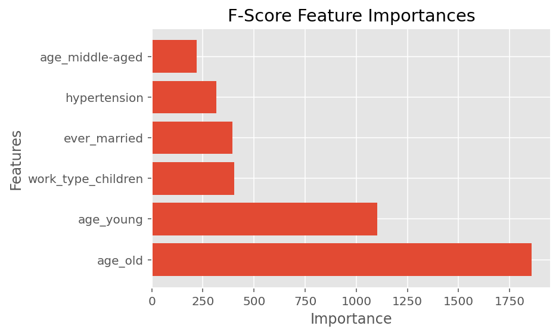

```python
plot_imp(best_features_fscore[5], feature_importances_fscore[5], 'F-Score')
```

Analysis : From the above visualisation we could see that age_old feature has the highest importance in the selected features list.

## Task 2.2) Model Fitting and Tuning:

### Algorithm 1 : KNN

```python
# select 3 different algorithms
# Apply hyperparameter tuning for each of these algorithms
# Visualise the hyperparameter tuning
```

###### Hyperparameter Tuning using GridSearchCV and Cross validation

```python
# define a dict of Knn parameters for grid search
params_KNN = {'n_neighbors': [1,2,3,4,5,6,7,8],
             'p':[1,2,5]}
```

```python
scoring_metric = 'roc_auc'

gs_Knn = GridSearchCV(estimator=KNeighborsClassifier(),
                     param_grid=params_KNN,
                     cv=cv_method,
                     verbose=1,
                     scoring=scoring_metric,
                     return_train_score=True)
```

```python
gs_Knn.fit(D_train_subset,t_train);
```

```
Fitting 15 folds for each of 24 candidates, totalling 360 fits
```

```
[Parallel(n_jobs=1)]: Using backend SequentialBackend with 1 concurrent workers.
[Parallel(n_jobs=1)]: Done 360 out of 360 | elapsed:   42.2s finished
```

```python
# determine the best parameters
gs_Knn.best_params_
```

```
{'n_neighbors': 8, 'p': 1}
```

```python
# mean cv score
gs_Knn.best_score_
```

```
0.6834150036954915
```

```python
results_Knn = pd.DataFrame(gs_Knn.cv_results_['params'])
results_Knn['test_score'] = gs_Knn.cv_results_['mean_test_score']
results_Knn['metric'] = results_Knn['p'].replace([1,2,5], ["Manhattan", "Euclidean", "Minkowski"])
results_Knn
```

|  | n_neighbors | p | test_score | metric |
| --- | --- | --- | --- | --- |
| 0 | 1 | 1 | 0.520041 | Manhattan |
| 1 | 1 | 2 | 0.520041 | Euclidean |
| 2 | 1 | 5 | 0.520041 | Minkowski |
| 3 | 2 | 1 | 0.634278 | Manhattan |
| 4 | 2 | 2 | 0.634278 | Euclidean |
| 5 | 2 | 5 | 0.634278 | Minkowski |
| 6 | 3 | 1 | 0.652058 | Manhattan |
| 7 | 3 | 2 | 0.652058 | Euclidean |
| 8 | 3 | 5 | 0.652058 | Minkowski |
| 9 | 4 | 1 | 0.657760 | Manhattan |
| 10 | 4 | 2 | 0.657760 | Euclidean |
| 11 | 4 | 5 | 0.657760 | Minkowski |
| 12 | 5 | 1 | 0.668894 | Manhattan |
| 13 | 5 | 2 | 0.668894 | Euclidean |
| 14 | 5 | 5 | 0.668894 | Minkowski |
| 15 | 6 | 1 | 0.678003 | Manhattan |
| 16 | 6 | 2 | 0.678003 | Euclidean |
| 17 | 6 | 5 | 0.678003 | Minkowski |
| 18 | 7 | 1 | 0.682537 | Manhattan |
| 19 | 7 | 2 | 0.682537 | Euclidean |
| 20 | 7 | 5 | 0.682537 | Minkowski |
| 21 | 8 | 1 | 0.683415 | Manhattan |
| 22 | 8 | 2 | 0.683415 | Euclidean |
| 23 | 8 | 5 | 0.683415 | Minkowski |

Conclusion : From the above table we can conclude that the test_score is the same for a particular value of n_neighbors irrespective of the Distance metric used. The best param values will be n_neighbors=8, p=1 with test score of 0.683415.

Ex: for n_neighbors = 1, the test_score value is 0.520041 irrespective of the distance metric used. So this will lead to overlapping of the lines in the visualisation.

##### Visualisation for performance of KNN Model:

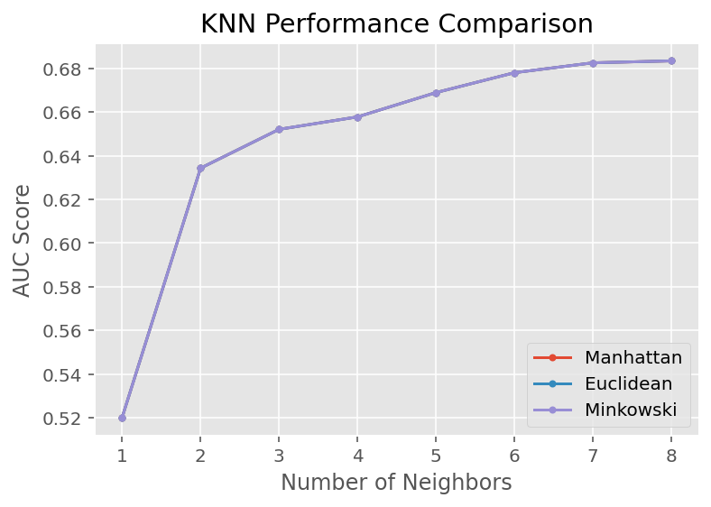

```python
import matplotlib.pyplot as plt
%matplotlib inline
%config InlineBackend.figure_format = 'retina'
plt.style.use("ggplot")

for i in ["Manhattan", "Euclidean", "Minkowski"]:
    temp = results_Knn[results_Knn['metric']==i]
    plt.plot(temp['n_neighbors'], temp['test_score'], marker = '.', label = i)

plt.legend()
plt.xlabel('Number of Neighbors')
plt.ylabel("AUC Score")
plt.title("KNN Performance Comparison")
plt.show()
```

### Algorithm 2 : Decision Tree

###### Hyperparameter Tuning using GridSearchCV and Cross validation

```python
# Hyperparameter tuning for decision tree
from sklearn.tree import DecisionTreeClassifier

df_classifer = DecisionTreeClassifier(random_state=999)

params_DT = {'criterion': ['gini', 'entropy'],
            'max_depth' : [1,2,3,4,5,6,7,8],
            'min_samples_split' : [2,3]}

gs_DT = GridSearchCV(estimator=df_classifer,
                    param_grid=params_DT,
                    cv = cv_method,
                    verbose=1,
                    scoring=scoring_metric)
gs_DT.fit(D_train_subset, t_train);
```

```
Fitting 15 folds for each of 32 candidates, totalling 480 fits
```

```
[Parallel(n_jobs=1)]: Using backend SequentialBackend with 1 concurrent workers.
[Parallel(n_jobs=1)]: Done 480 out of 480 | elapsed:    1.0s finished
```

```python
# determine the best parameters
gs_DT.best_params_
```

```
{'criterion': 'gini', 'max_depth': 4, 'min_samples_split': 2}
```

```python
gs_DT.best_score_
```

```
0.8234693274205471
```

```python
results_DT = pd.DataFrame(gs_DT.cv_results_['params'])
results_DT['test_score'] = gs_DT.cv_results_['mean_test_score']
results_DT
```

|  | criterion | max_depth | min_samples_split | test_score |
| --- | --- | --- | --- | --- |
| 0 | gini | 1 | 2 | 0.774115 |
| 1 | gini | 1 | 3 | 0.774115 |
| 2 | gini | 2 | 2 | 0.814866 |
| 3 | gini | 2 | 3 | 0.814866 |
| 4 | gini | 3 | 2 | 0.822293 |
| 5 | gini | 3 | 3 | 0.822293 |
| 6 | gini | 4 | 2 | 0.823469 |
| 7 | gini | 4 | 3 | 0.823469 |
| 8 | gini | 5 | 2 | 0.823469 |
| 9 | gini | 5 | 3 | 0.823469 |
| 10 | gini | 6 | 2 | 0.823469 |
| 11 | gini | 6 | 3 | 0.823469 |
| 12 | gini | 7 | 2 | 0.823469 |
| 13 | gini | 7 | 3 | 0.823469 |
| 14 | gini | 8 | 2 | 0.823469 |
| 15 | gini | 8 | 3 | 0.823469 |
| 16 | entropy | 1 | 2 | 0.774115 |
| 17 | entropy | 1 | 3 | 0.774115 |
| 18 | entropy | 2 | 2 | 0.814866 |
| 19 | entropy | 2 | 3 | 0.814866 |
| 20 | entropy | 3 | 2 | 0.822293 |
| 21 | entropy | 3 | 3 | 0.822293 |
| 22 | entropy | 4 | 2 | 0.823469 |
| 23 | entropy | 4 | 3 | 0.823469 |
| 24 | entropy | 5 | 2 | 0.823469 |
| 25 | entropy | 5 | 3 | 0.823469 |
| 26 | entropy | 6 | 2 | 0.823469 |
| 27 | entropy | 6 | 3 | 0.823469 |
| 28 | entropy | 7 | 2 | 0.823469 |
| 29 | entropy | 7 | 3 | 0.823469 |
| 30 | entropy | 8 | 2 | 0.823469 |
| 31 | entropy | 8 | 3 | 0.823469 |

Conclusion : The min_samples_split does not influence the test-score much. The test_score is same for a particular max depth , irrespective of the criterion.

#### Visualisation for Performance of Decision Tree Model:

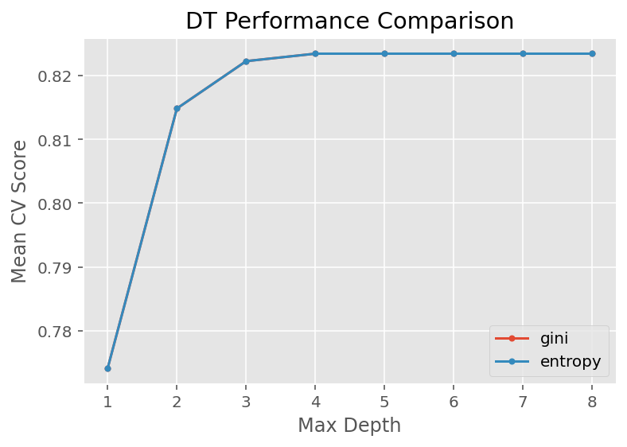

```python
for i in ['gini', 'entropy']:
    temp = results_DT[results_DT['criterion'] == i]
    temp_average = temp.groupby('max_depth').agg({'test_score': 'mean'})
    plt.plot(temp_average, marker = '.', label = i)


plt.legend()
plt.xlabel('Max Depth')
plt.ylabel("Mean CV Score")
plt.title("DT Performance Comparison")
plt.show()
```

Analysis : As stated in the above conclusion the lines for entropy and gini are overlapped. We can see from the visualisation that the AUC score is the highest when max_depth = 4.

## Algorithm 3 : Random Forest

```python
# Hyperparameter tuning for decision tree
from sklearn.ensemble import RandomForestClassifier

RF_classifier = RandomForestClassifier(random_state=999)

params_RF = {'criterion': ['gini', 'entropy'],
            'max_depth' : [1,2,3,4,5,6,7,8],
            'n_estimators': [25,50]}

gs_RF = GridSearchCV(estimator=RF_classifier,
                    param_grid=params_RF,
                    cv = cv_method,
                    verbose=1,
                    scoring=scoring_metric)
gs_RF.fit(D_train_subset, t_train);
```

```
Fitting 15 folds for each of 32 candidates, totalling 480 fits
```

```
[Parallel(n_jobs=1)]: Using backend SequentialBackend with 1 concurrent workers.
[Parallel(n_jobs=1)]: Done 480 out of 480 | elapsed:   25.5s finished
```

```python
gs_RF.best_params_
```

```
{'criterion': 'gini', 'max_depth': 5, 'n_estimators': 25}
```

```python
gs_RF.best_score_
```

```
0.8234438285291944
```

```python
results_RF = pd.DataFrame(gs_RF.cv_results_['params'])
results_RF['test_score'] = gs_RF.cv_results_['mean_test_score']
results_RF
```

|  | criterion | max_depth | n_estimators | test_score |
| --- | --- | --- | --- | --- |
| 0 | gini | 1 | 25 | 0.804254 |
| 1 | gini | 1 | 50 | 0.804254 |
| 2 | gini | 2 | 25 | 0.820586 |
| 3 | gini | 2 | 50 | 0.819672 |
| 4 | gini | 3 | 25 | 0.822709 |
| 5 | gini | 3 | 50 | 0.823200 |
| 6 | gini | 4 | 25 | 0.823382 |
| 7 | gini | 4 | 50 | 0.823384 |
| 8 | gini | 5 | 25 | 0.823444 |
| 9 | gini | 5 | 50 | 0.823410 |
| 10 | gini | 6 | 25 | 0.823444 |
| 11 | gini | 6 | 50 | 0.823410 |
| 12 | gini | 7 | 25 | 0.823444 |
| 13 | gini | 7 | 50 | 0.823410 |
| 14 | gini | 8 | 25 | 0.823444 |
| 15 | gini | 8 | 50 | 0.823410 |
| 16 | entropy | 1 | 25 | 0.806552 |
| 17 | entropy | 1 | 50 | 0.804254 |
| 18 | entropy | 2 | 25 | 0.820185 |
| 19 | entropy | 2 | 50 | 0.820185 |
| 20 | entropy | 3 | 25 | 0.822709 |
| 21 | entropy | 3 | 50 | 0.823200 |
| 22 | entropy | 4 | 25 | 0.823439 |
| 23 | entropy | 4 | 50 | 0.823418 |
| 24 | entropy | 5 | 25 | 0.823444 |
| 25 | entropy | 5 | 50 | 0.823410 |
| 26 | entropy | 6 | 25 | 0.823444 |
| 27 | entropy | 6 | 50 | 0.823410 |
| 28 | entropy | 7 | 25 | 0.823444 |
| 29 | entropy | 7 | 50 | 0.823410 |
| 30 | entropy | 8 | 25 | 0.823444 |
| 31 | entropy | 8 | 50 | 0.823410 |

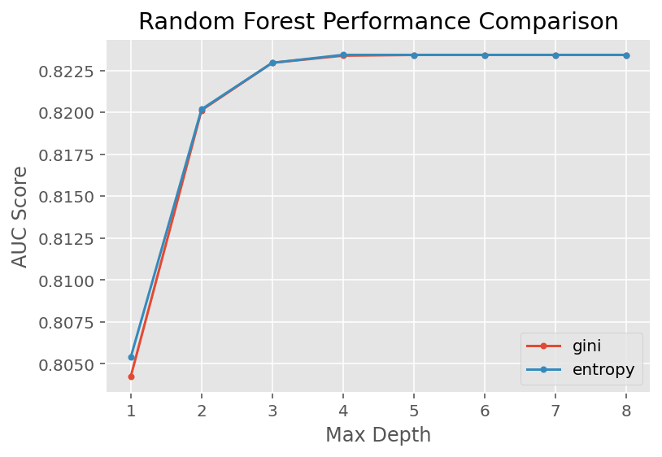

```python
for i in ['gini', 'entropy']:
    temp = results_RF[results_RF['criterion'] == i]
    temp_average = temp.groupby('max_depth').agg({'test_score': 'mean'})
    plt.plot(temp_average, marker = '.', label = i)


plt.legend()
plt.xlabel('Max Depth')
plt.ylabel("AUC Score")
plt.title("Random Forest Performance Comparison")
plt.show()
```

Analysis : From the above visualisation we can see that AUC score is high when max_depth = 5.

## Task 2.3) Model Comparision:

The 3 models will be compared using the ROC_AUC metric score for paired t-tests

##### Visualisation of ROC-AUC curves for each of the model:

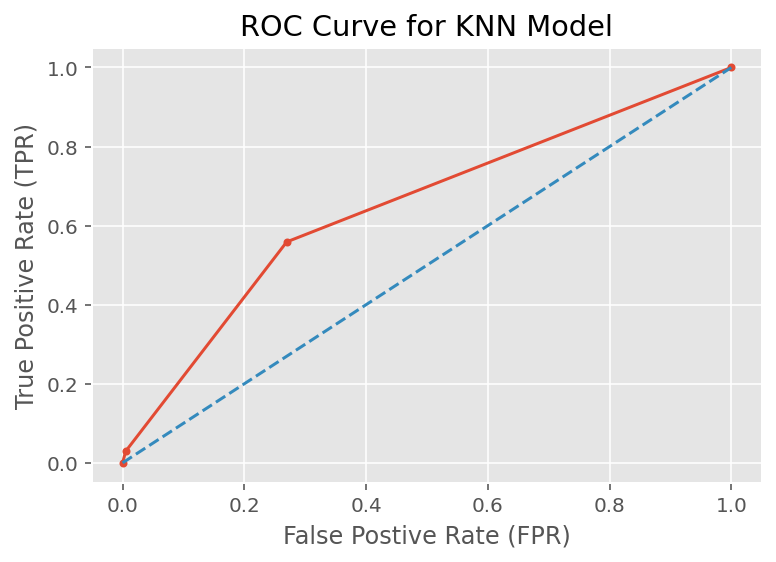

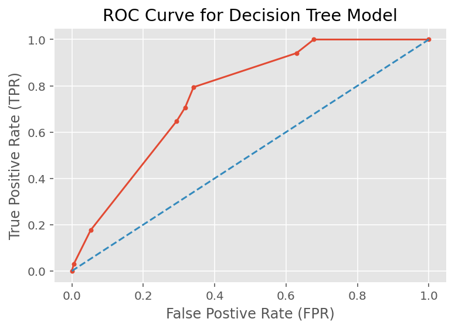

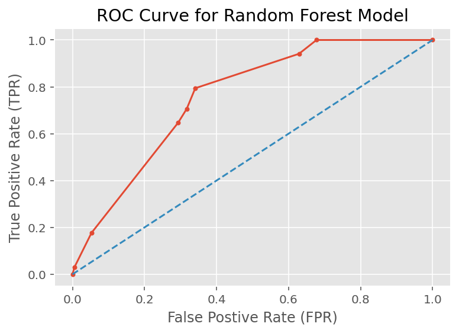

```python
# For KNN
# find the probailities
t_prob = gs_Knn.predict_proba(D_test_subset)
t_prob[0:10]

# create a table using fpr(False positive rate) and tpr(True Positive Rate)
fpr, tpr, _ = metrics.roc_curve(t_test, t_prob[:, 1])
roc_auc = metrics.auc(fpr, tpr)

df = pd.DataFrame({'fpr': fpr, 'tpr': tpr})


plt.style.use("ggplot")

ax = df.plot.line(x='fpr', y='tpr', title='ROC Curve for KNN Model', legend=False, marker = '.')
plt.plot([0, 1], [0, 1], '--')
ax.set_xlabel("False Postive Rate (FPR)")
ax.set_ylabel("True Positive Rate (TPR)")
plt.show();

# --------------------------------------------------------------------------------------------

# Roc Curve Visualisation for Decision tree
t_prob = gs_DT.predict_proba(D_test_subset)
t_prob[0:10]

fpr, tpr, _ = metrics.roc_curve(t_test, t_prob[:, 1])
roc_auc = metrics.auc(fpr, tpr)
roc_auc

import pandas as pd
df = pd.DataFrame({'fpr': fpr, 'tpr': tpr})
df

plt.style.use("ggplot")

ax = df.plot.line(x='fpr', y='tpr', title='ROC Curve for Decision Tree Model', legend=False, marker = '.')
plt.plot([0, 1], [0, 1], '--')
ax.set_xlabel("False Postive Rate (FPR)")
ax.set_ylabel("True Positive Rate (TPR)")
plt.show();

# --------------------------------------------------------------------------------------------------

# Roc curve visualisation for Random Forest
t_prob = gs_RF.predict_proba(D_test_subset)

fpr, tpr, _ = metrics.roc_curve(t_test, t_prob[:, 1])
roc_auc = metrics.auc(fpr, tpr)
df = pd.DataFrame({'fpr': fpr, 'tpr': tpr})


plt.style.use("ggplot")

ax = df.plot.line(x='fpr', y='tpr', title='ROC Curve for Random Forest Model', legend=False, marker = '.')
plt.plot([0, 1], [0, 1], '--')
ax.set_xlabel("False Postive Rate (FPR)")
ax.set_ylabel("True Positive Rate (TPR)")
plt.show();
```

Analysis : As the TPR increases the FPR also increases. Considering our problem statement of stroke prediction we would like the TPR(Recall) to be high. So the best model is the one which has higher AUC(Area Under the Curve). By comparing the above three visualisations we can conclude that, both Decision tree and Random Forest have similar AUC and are better compared to the KNN model.

## Paired T-test:

```python
cv_method_ttest = RepeatedStratifiedKFold(n_splits=5,
                                          n_repeats=5,
                                          random_state=111)

cv_results_KNN = cross_val_score(estimator=gs_Knn.best_estimator_,
                                 X=D_test_subset,
                                 y=t_test,
                                 cv=cv_method_ttest,
                                 n_jobs=-2,
                                 scoring='roc_auc')

cv_results_DT = cross_val_score(estimator= gs_DT.best_estimator_,
                                X=D_test_subset,
                                y=t_test,
                                cv=cv_method_ttest,
                                n_jobs=-2,
                                scoring='roc_auc')

cv_results_RF = cross_val_score(estimator= gs_RF.best_estimator_,
                                X=D_test_subset,
                                y=t_test,
                                cv=cv_method_ttest,
                                n_jobs=-2,
                                scoring='roc_auc')

roc_auc_score_df = pd.DataFrame(columns= ['Model', 'ROC_AUC score'])
roc_auc_score_df.loc[len(roc_auc_score_df)] = ['Decision Tree', cv_results_DT.mean()]
roc_auc_score_df.loc[len(roc_auc_score_df)] = ['Random Forest', cv_results_RF.mean()]
roc_auc_score_df.loc[len(roc_auc_score_df)] = ['KNN', cv_results_KNN.mean()]
roc_auc_score_df
```

|  | Model | ROC_AUC score |
| --- | --- | --- |
| 0 | Decision Tree | 0.727010 |
| 1 | Random Forest | 0.726955 |
| 2 | KNN | 0.578714 |

```python
paired_ttest_res_df = pd.DataFrame(columns=['Model 1', 'Model 2', 'p-value','Statistically Significant'])
paired_ttest_res_df.loc[len(paired_ttest_res_df)] = ['KNN', 'Decision Tree',
                                                     stats.ttest_rel(cv_results_KNN, cv_results_DT)[1], 'Yes']
paired_ttest_res_df.loc[len(paired_ttest_res_df)] = ['Decision Tree','Random Forest',
                                                     stats.ttest_rel(cv_results_DT, cv_results_RF)[1], 'No']
paired_ttest_res_df.loc[len(paired_ttest_res_df)] = ['KNN', 'Random Forest',
                                                     stats.ttest_rel(cv_results_KNN, cv_results_RF)[1], 'Yes']

paired_ttest_res_df
```

|  | Model 1 | Model 2 | p-value | Statistically Significant |
| --- | --- | --- | --- | --- |
| 0 | KNN | Decision Tree | 3.103465e-09 | Yes |
| 1 | Decision Tree | Random Forest | 9.894393e-01 | No |
| 2 | KNN | Random Forest | 7.856377e-09 | Yes |

Analysis : From the above tables we can conclude that there is a statistical significant difference between KNN and other models. But the paired t-test comparision between Random Forest and Decision Tree reveals that both are comparable models as there is no statistical significance difference between them as the ROC_AUC Score of Decision Tree is slighlty higher than that of Random Forest.

##### Comparision Using Classification Report and Confusion Matrix:

```python
# store each of the prediction values in the corresponding variables
pred_knn = gs_Knn.predict(D_test_subset)
pred_dt = gs_DT.predict(D_test_subset)
pred_rf = gs_RF.predict(D_test_subset)
```

```python
print("\nClassification report for K-Nearest Neighbor")
print(metrics.classification_report(t_test, pred_knn))
print("\nClassification report for Decision Tree")
print(metrics.classification_report(t_test, pred_dt))
print("\nClassification report for Random Forest")
print(metrics.classification_report(t_test, pred_rf))
```

```
Classification report for K-Nearest Neighbor
              precision    recall  f1-score   support

           0       0.97      1.00      0.98       968
           1       0.00      0.00      0.00        34

    accuracy                           0.97      1002
   macro avg       0.48      0.50      0.49      1002
weighted avg       0.93      0.97      0.95      1002


Classification report for Decision Tree
              precision    recall  f1-score   support

           0       0.99      0.66      0.79       968
           1       0.08      0.79      0.14        34

    accuracy                           0.66      1002
   macro avg       0.53      0.73      0.46      1002
weighted avg       0.96      0.66      0.77      1002


Classification report for Random Forest
              precision    recall  f1-score   support

           0       0.99      0.66      0.79       968
           1       0.08      0.79      0.14        34

    accuracy                           0.66      1002
   macro avg       0.53      0.73      0.46      1002
weighted avg       0.96      0.66      0.77      1002
```

```python
print("\n Confusion matrix for K-Nearest Neighbor")
print(metrics.confusion_matrix(t_test, pred_knn))
print("\n Confusion matrix for Decision Tree")
print(metrics.confusion_matrix(t_test, pred_dt))
print("\n Confusion matrix for Random Forest")
print(metrics.confusion_matrix(t_test, pred_rf))
```

```
 Confusion matrix for K-Nearest Neighbor
[[968   0]
 [ 34   0]]

 Confusion matrix for Decision Tree
[[638 330]
 [  7  27]]

 Confusion matrix for Random Forest
[[638 330]
 [  7  27]]
```

As the dataset depends on the prediction of stroke we would like to select the recall to assess the performance of the classifier. Because we would want a patient with stroke to be classified as stroke(target class =1). This would lead to a trade off as higher TPR leads to Higher FPR. This would lead to classifying a healthy indvidual as a patient with stroke and we have to make this compromise. But we would not want our model to predict a patient with stroke as no stroke (target class = 0).

### Task 3: Critique & Limitations:

Weakness:

- The age_old feature has the highest feature importance and hence it contributes more to the model. So this is the main reason for overlapping of the lines in the visualisation for Knn and Decision Tree. Example : Incase of KNN, the model predicts same score for a particular value of n_neighbors even though the value of p is changed. Since the whole model is more dependent on the age_old variable this might lead to overfitting.

### Task 4) Summary and conclusions:

#### Task 4.1) Project Summary:

Phase 1:

- I preprocessed the data by removing the missing values and setting the irrelevant feature 'id' as index.
- Removed the outliers in the data by excluding the values which were less than (Q1 - 1.5 *IQR) and higher than (Q3 + 1.5* IQR).
- I had to drop the records like gender='other' as it had only one record and as it won't contribute to the model prediction.
- Used 1-variable, 2-variable and 3-variable plots to get the insights from the data.

Phase 2:

- I had to bin the descriptive feature age and did one hot encoding for the nominal variables.
- Had to split the data into features and target and label encoding of the target variable stroke.
- Normalise the numerical descriptive features using MinMaxScaler()
- split the dataset into train and test (70:30).
- I performed the oversampling of the minority class(stroke = 1) in the training data to resolve the imbalance data issue.
- Found the best features using the feature selection method F-score.
- Using the best features I fit three models (KNN, Decision Tree and Random Forest) and did hyperparameter tuning using GridSearchCV and cross validation and compared the performance using roc_auc as the metric.
- Once the models were tuned , cross validation was performed using the tuned models on the test set and performed paired t-test to check for statistical significant difference between the performance of the models.
- The models were further compared using the Confusion matrix and the Recall score.

#### Task 4.2) Summary of Findings:

From Phase 1: The insights gained from the variables, include indviduals with age between 55 and 85 , hypertension = 1, bmi greater than 25 and gender = female are more prone to stroke.

From Phase 2:

- The individuals in age_old(53.0, 82.0) range are more prone to stroke.
- The indivdiuals with hypertension are more prone to stroke.
- The best features which contribute more to the model include age_old, age_young, work_type_children, ever_married, hypertension, age_middle_aged.

#### Task 4.3) Conclusions:

The main aim of this project is to predict whether an individual will have a stroke based on the input features. After the phase 1 insights gained from these variables, we concluded that indviduals with age between 55 and 85 , hypertension = 1, bmi greater than 25 and gender = female are more prone to stroke. But after completing the phase 2 we are assured that old people(age-53 to 82) and individuals with hypertension are more prone to stroke. The old_age feature contributes more to the model as it has the highest feature importance among the selected features. Although the performance of Decision tree and Random Forest is equal. The decision tree would be better if we select based on the comptutational time as it gives the same performance score as Random Forest in less computational time.

## References:

1. How to Deal with Imbalanced Data (2020). Available at: https://towardsdatascience.com/how-to-deal-with-imbalanced-data-34ab7db9b100
2. Case Study: Predicting Income Status | www.featureranking.com (2021). Available at: https://www.featureranking.com/tutorials/machine-learning-tutorials/case-study-predicting-income-status/#2
3. SK Part 4: Model Evaluation | www.featureranking.com (2021). Available at: https://www.featureranking.com/tutorials/machine-learning-tutorials/sk-part-4-model-evaluation/
4. SK Part 2: Feature Selection and Ranking | www.featureranking.com (2021). Available at: https://www.featureranking.com/tutorials/machine-learning-tutorials/sk-part-2-feature-selection-and-ranking/